# Lista05

Guilherme Pazian

4 de abril de 2017

```r
TeachingRatings <- read.csv("TeachingRatings.csv", dec = ",")
```

# a) Faça um gráfico de dispersão para Course-Eval e Beauty. Existe relação entre as avaliações e a beleza do professor?

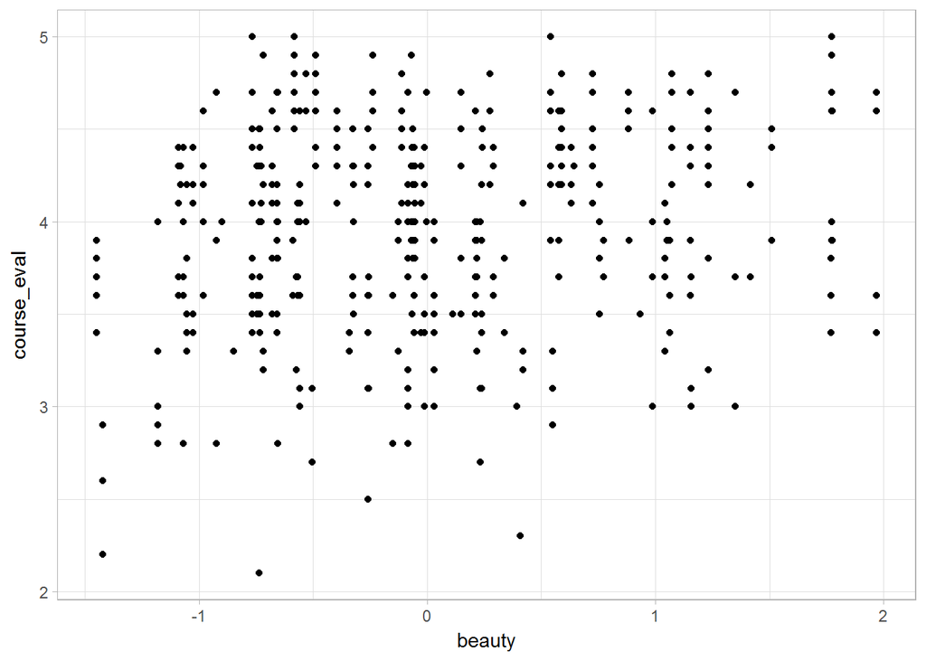

```r
library(ggplot2)

ggplot(data = TeachingRatings) +
  geom_point(aes(beauty, course_eval)) + theme_light()
```

Pode-se observar por meio do gráfico acima que existe correlação linear entre as variáveis, apesar dessa relação não ser muito forte.

# b) Faça a regressão considerando Course-Eval como variável resposta e Beauty como variável explanatória.O efeito da beleza do professor na avaliação é grande ou pequeno?

```r
library(printr)

library(AER)

fit1 <- lm(course_eval~beauty,data = TeachingRatings)

robust.fit1 <- vcovHC(fit1, type = "HC1")

coeficientes.fit1 <-coeftest(fit1, robust.fit1)
coeficientes.fit1
```

```
##
## t test of coefficients:
##
##             Estimate Std. Error  t value  Pr(>|t|)
## (Intercept) 3.998272   0.025349 157.7272 < 2.2e-16 ***
## beauty      0.133001   0.032319   4.1153 4.581e-05 ***
## ---
## Signif. codes:  0 '***' 0.001 '**' 0.01 '*' 0.05 '.' 0.1 ' ' 1
```

```r
r2x <- summary(fit1)$r.squared
r2ajustx <- summary(fit1)$adj.r.squared
```

A estimativa do parâmetro $\beta_1$ apresentada foi: 0.133, apesar de não apresentar um valor muito alto, vemos, pela tabela acima, que ele é estatísticamente significativo. Portanto o efeito da beleza do professor é significativo quando comparado com a avaliação.

Neste ajuste observamos um valor para $R^2$ de 0.036 e um valor de $\bar{R}^2$ de 0.034.

# c) Faça a regressão considerando Course-Eval como variável resposta e como variáveis explanatórias Beauty, Intro, OneCredit, Female, Minority e NNEnglish. Qual o efeito da beleza do professor nas avaliações? Compare esse resultado com (b); há viés por omissão de variável?

```r
fit2 <- lm(course_eval~beauty + female + minority + nnenglish + intro + onecredit + age, data = TeachingRatings)

robust.fit2 <- vcovHC(fit2, type = "HC1")

coeficientes.fit2 <-coeftest(fit2, robust.fit2)
coeficientes.fit2
```

```
##
## t test of coefficients:
##
##               Estimate Std. Error t value  Pr(>|t|)
## (Intercept)  4.1685300  0.1390349 29.9819 < 2.2e-16 ***
## beauty       0.1592092  0.0306846  5.1886 3.198e-07 ***
## female      -0.1832345  0.0521947 -3.5106 0.0004917 ***
## minority    -0.1694282  0.0678910 -2.4956 0.0129279 *
## nnenglish   -0.2438402  0.0958959 -2.5428 0.0113283 *
## intro        0.0079489  0.0565469  0.1406 0.8882710
## onecredit    0.6329999  0.1077655  5.8739 8.228e-09 ***
## age         -0.0019545  0.0026218 -0.7455 0.4563667
## ---
## Signif. codes:  0 '***' 0.001 '**' 0.01 '*' 0.05 '.' 0.1 ' ' 1
```

Observe pela tabela acima que o coeficiente estimado para o parâmetro referente à variável “beauty” continua sendo significativo, a estimativa para este mesmo parâmetro agora é 0.1592, e teve uma mudança de 0.026, ou seja, teve uma mudança muito pequena, portanto não ocorreu viés por omissão de variável.

```r
cor(TeachingRatings)
```

|  | minority | age | female | onecredit | beauty | course_eval | intro | nnenglish |
| --- | --- | --- | --- | --- | --- | --- | --- | --- |
| minority | 1.0000000 | -0.1031201 | 0.1146425 | 0.2474896 | 0.0330600 | -0.0766545 | 0.1361286 | 0.2921864 |
| age | -0.1031201 | 1.0000000 | -0.2850877 | -0.0252771 | -0.2978925 | -0.0516962 | -0.0914632 | -0.0020545 |
| female | 0.1146425 | -0.2850877 | 1.0000000 | -0.0442683 | 0.1257194 | -0.1496600 | -0.0565793 | 0.0038051 |
| onecredit | 0.2474896 | -0.0252771 | -0.0442683 | 1.0000000 | -0.0847036 | 0.2352395 | 0.3279467 | -0.0244691 |
| beauty | 0.0330600 | -0.2978925 | 0.1257194 | -0.0847036 | 1.0000000 | 0.1890391 | 0.0325769 | 0.0102933 |
| course_eval | -0.0766545 | -0.0516962 | -0.1496600 | 0.2352395 | 0.1890391 | 1.0000000 | 0.1150025 | -0.1414346 |
| intro | 0.1361286 | -0.0914632 | -0.0565793 | 0.3279467 | 0.0325769 | 0.1150025 | 1.0000000 | -0.1434483 |
| nnenglish | 0.2921864 | -0.0020545 | 0.0038051 | -0.0244691 | 0.0102933 | -0.1414346 | -0.1434483 | 1.0000000 |

# d) O professor Smith é negro com Beauty igual à média dessa variável, é falante de inglês nativo e ensina uma disciplina de três créditos. Calcule a previsão da avaliação do professor.

Considerando que o curso NÃO é introdutório e que SmithnI têm idade igual a média observada para a variável “age” no banco de dados:

```r
SmithnI <- c(mean(TeachingRatings$beauty),0,1,0,0,0, mean(TeachingRatings$age))
previsaonI <- sum(c(coeficientes.fit2[1,1], coeficientes.fit2[-1,1] * SmithnI))
```

No caso em que consideramos o curso dado por Smith como não introdutório, temos que a previsão de avaliação do professor é dada por : 3.905

Considerando que o curso é introdutório e que SmithnI têm idade igual a média observada para a variável “age” no banco de dados:

```r
SmithI <- c(mean(TeachingRatings$beauty),0,1,0,1,0,mean(TeachingRatings$age))
previsaoI <- sum(c(coeficientes.fit2[1,1], coeficientes.fit2[-1,1] * SmithI))
```

No caso em que consideramos o curso dado por Smith como introdutório, temos que a previsão de avaliação do professor é dada por : 3.913

# e) Calcule o R2 e $\bar{R}^2$. Discuta os resultados.

```r
r2 <- summary(fit2)$r.squared
r2ajust <- summary(fit2)$adj.r.squared
```

$R^2$ = 0.1556

$\bar{R}^2$ = 0.1427